# Beer And Breweries

## Hops causes IBU (bitterness) while malt and sugar cause ABV (alcohol content). So understanding how this works, this correlation should be due to the choices of the brewers, adding increasing Hops and malt/sugar to their beer, and not causition.

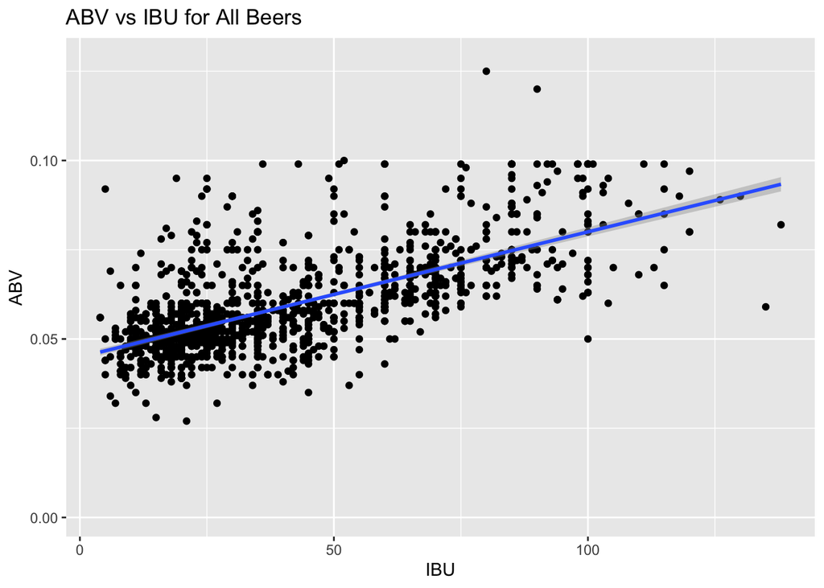

```r
# show a scatterplot of relationship betweeen bitterness (ABV) and alcoholic content (ABV).
# fit the curve using a line



# should we NOT include the NA's here? It's very distinctive and probably throws things off
ggplot(dfFull, aes(x=dfFull$ibu, y=dfFull$abv)) + geom_point() + geom_smooth(method=lm) +
  xlab("IBU") + ylab("ABV") + ggtitle("ABV vs IBU for All Beers")
```

## 8. Budweiser would also like to investigate the difference with respect to IBU and ABV between IPAs (India Pale Ales) and other types of Ale (any beer with “Ale” in its name other than IPA). You decide to use KNN clustering to investigate this relationship. Provide statistical evidence one way or the other. You can of course assume your audience is comfortable with percentages … KNN is very easy to understand.

## The following diagram shows the IBU and ABV for individual IPA and Other Ales beers - red indicates IPA, blue indicates Other Ales. The red and blue ellipses shows a confidence interval for the values of each beer type - basically where we expect beers of that type to be based on their mean and standard deviation.

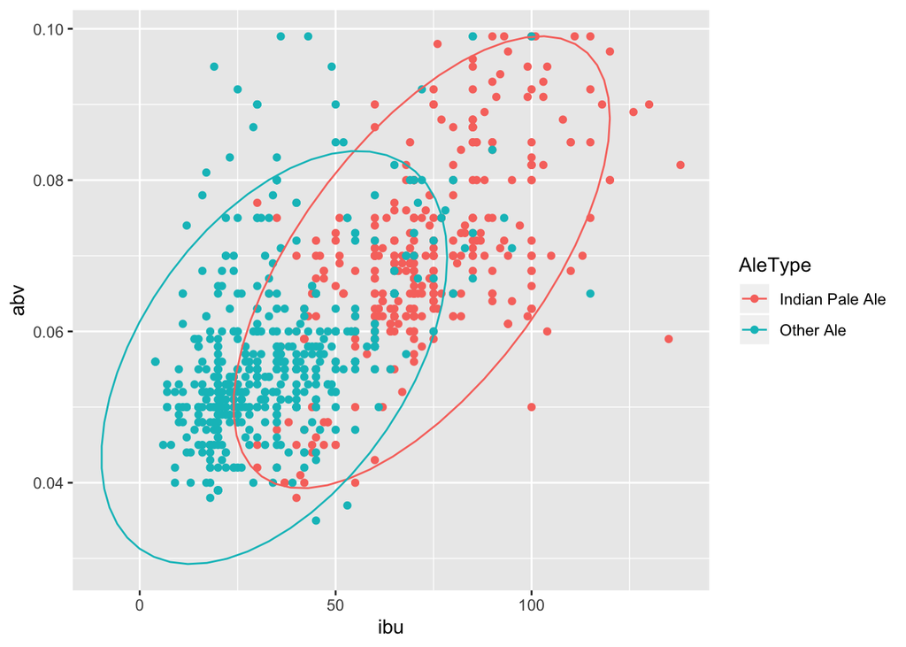

```r
#library(stringr)
# filter out Indian Pale Ales and other types of "Ale"
#dfFull
dfIndianPaleAles <- dfFull %>% filter(str_detect(style, "IPA"))
#dfIndianPaleAles
dfOtherAles <- dfFull %>% filter((str_detect(style, "Ale"))) %>% filter(!str_detect(style,"IPA"))
#dfOtherAles


# Might need to give an additional attribute to indicate if the beer is an IPA or other type
dfIndianPaleAles <- dfIndianPaleAles %>% mutate(AleType = 'Indian Pale Ale')
#dfIndianPaleAles
dfOtherAles <- dfOtherAles %>% mutate(AleType ='Other Ale')
#dfOtherAles



dfAllAles <- rbind(dfIndianPaleAles,dfOtherAles)
#dfAllAles

dfAllAles <- dfAllAles %>% filter(!is.na(dfAllAles$abv))
dfAllAles <- dfAllAles %>% filter(!is.na(dfAllAles$ibu))




# show a scatterplot of IBU and ABV with color coding or different symbol for IPA and Ale

# Ellipse by groups
p <- ggplot(dfAllAles, aes(ibu, abv, color = AleType))+
  geom_point()
# Change the type of ellipses: possible values are "t", "norm", "euclid"
p + stat_ellipse(type = "norm")
```

```r
# https://ggplot2.tidyverse.org/reference/stat_ellipse.html
#  default "t" assumes a multivariate t-distribution, and "norm" assumes a multivariate normal distribution
```

## use KNN to classify other ale vs pale ale and check the results

## The following code tests various k values with the K nearest neighbor algorithm to find the best accuracy. The first diagram shows the accuracy vs. k value. Additional diagrams show the sensitivity and specificity vs. K value.

## using a k value of around 30 looks good, giving accuracy = 0.84, sensitivity = 0.79, and specificity = 0.88.

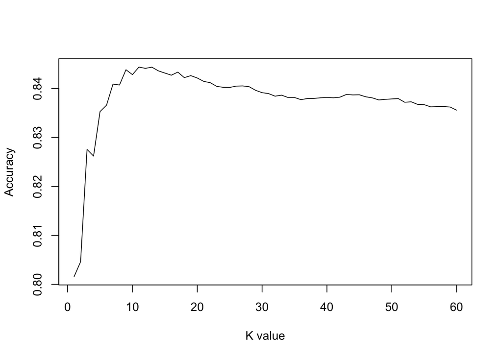

```r
# use KNN to predict the group membership and see if it works.
#

# remove the rows with no ABV or no IBU


# KNN Loop for average of many training / test partition
# Loop for many k and the average of many training / test partition
#library(class)
#library(caret)
#library(e1071)


set.seed(1)
splitPerc = .7
iterations = 100
numks = 60
masterAcc = matrix(nrow = iterations, ncol = numks)
masterSpec = matrix(nrow = iterations, ncol = numks)
masterSens = matrix(nrow = iterations, ncol = numks)


for(j in 1:iterations)
{
trainIndices = sample(1:dim(dfAllAles)[1],round(splitPerc * dim(mpg)[1]))
train = dfAllAles[trainIndices,]
test = dfAllAles[-trainIndices,]
for(i in 1:numks)
{
  classifications = knn(scale(train[,c(3,4)]),scale(test[,c(3,4)]),as.factor(train$AleType), prob = TRUE, k = i)
  table(as.factor(test$AleType),classifications)
  CM = confusionMatrix(table(as.factor(test$AleType),classifications))
  masterAcc[j,i] = CM$overall[1]
  masterSens[j,i] = CM$byClass[1][[1]] # sensitivity
  masterSpec[j,i] = CM$byClass[2][[1]] # specificity
}

}

MeanAcc = colMeans(masterAcc)

plot(seq(1,numks,1),MeanAcc, type = "l", xlab = "K value", ylab="Accuracy")
```

```r
which.max(MeanAcc)
```

```
## [1] 11
```

```r
max(MeanAcc)
```

```
## [1] 0.844359
```

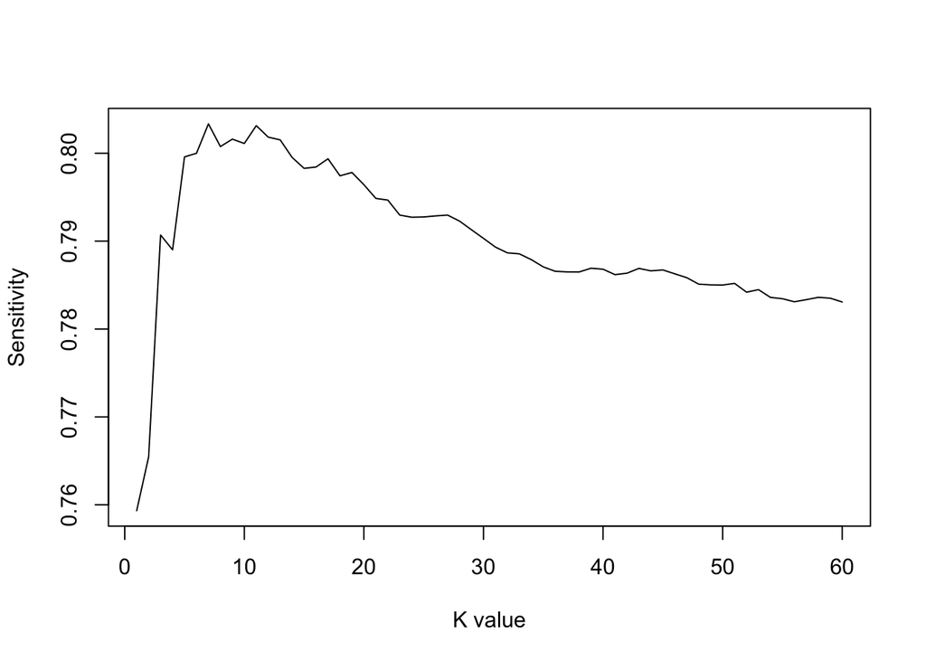

```r
MeanSens = colMeans(masterSens)

plot(seq(1,numks,1),MeanSens, type = "l", xlab = "K value", ylab="Sensitivity")
```

```r
which.max(MeanSens)
```

```
## [1] 7
```

```r
max(MeanSens)
```

```
## [1] 0.8033426
```

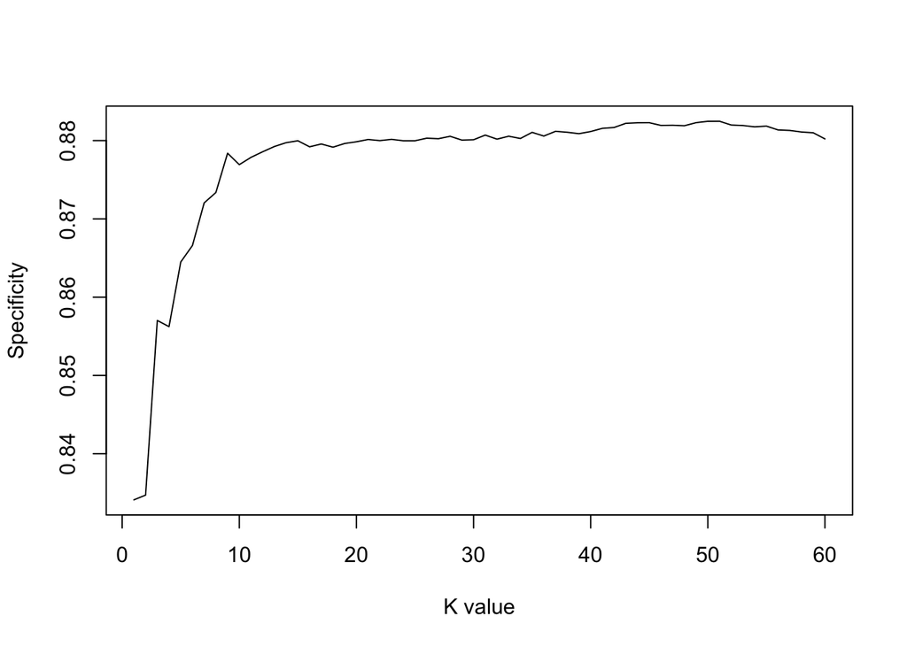

```r
MeanSpec = colMeans(masterSpec)

plot(seq(1,numks,1),MeanSpec, type = "l", xlab = "K value", ylab="Specificity")
```

```r
which.max(MeanSpec)
```

```
## [1] 51
```

```r
max(MeanSpec)
```

```
## [1] 0.8824686
```

### Check the accuracy, sensitivity and specificy for the “best” k value

```r
MeanAcc[11]
```

```
## [1] 0.844359
```

```r
MeanSens[11]
```

```
## [1] 0.8031408
```

```r
MeanSpec[11]
```

```
## [1] 0.8778584
```

## let’s try to make a graph of the decision boundaries.

## https://stackoverflow.com/questions/31234621/variation-on-how-to-plot-decision-boundary-of-a-k-nearest-neighbor-classifier-f/31236327

## using this display of the decision boundaries we can see that really the best indicator of IPA vs other all is IBU

## above around 60 (slightly less of higher ABV)

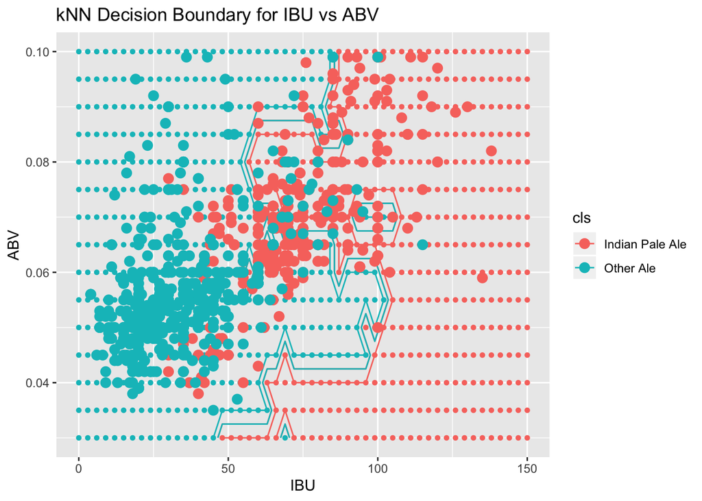

```r
require(MASS)
#library(MASS)


# more detailed
test <- expand.grid(IBU=seq(0, 150,
                           by=3),
                     ABV=seq(0.03, 0.1,
                           by=0.005))



require(class)
#library(class)



classif <- knn(scale(dfAllAles[,c(4,3)]),scale(test),dfAllAles$AleType, prob = TRUE, k = 11)
prob <- attr(classif, "prob")


#library(dplyr)

dataf <- bind_rows(mutate(test,
                         prob=prob,
                         cls="Indian Pale Ale",
                         prob_cls=ifelse(classif==cls,
                                         1, 0)),
                  mutate(test,
                         prob=prob,
                         cls="Other Ale",
                         prob_cls=ifelse(classif==cls,
                                         1, 0)))


ggplot(dataf, title="kNN Decision Boundary for IBU vs ABV") +
  ggtitle("kNN Decision Boundary for IBU vs ABV") +
  geom_point(aes(x=IBU, y=ABV, col=cls),
             data = mutate(test, cls=classif),
             size=1.2) +
  geom_contour(aes(x=IBU, y=ABV, z=prob_cls, group=cls, color=cls),
               bins=2,
               data=dataf) +
  geom_point(aes(x=IBU, y=ABV, col=cls),
             size=3,
             data=data.frame(IBU=dfAllAles$ibu, ABV=dfAllAles$abv, cls=dfAllAles$AleType))
```

## 9. Knock their socks off! Find one other useful inference from the data that you feel Budweiser may be able to find value in. You must convince them why it is important and back up your conviction with appropriate statistical evidence.